# HW1_solutions_rev_1

ECON GA-1101.003

Applied Statistics and Econometrics I

Fall 2021

## Homework 1 - Suggested Solutions

##### For the latest HTML version click [here](https://ciresar.github.io/HW1_solutions_embed.html)

### Problem 1:

Show that $E(Y)=\left(\theta_{1}+\theta_{2}\right) / 2$ when $Y$ is a uniformly distributed random variable on the interval $\left(\theta_{1}, \theta_{2}\right) .$

The expected value of a random variable is defined as (see [Greene Appendix B](http://pages.stern.nyu.edu/~wgreene/Text/Greene-EA-7&8ed-Appendices.pdf)):

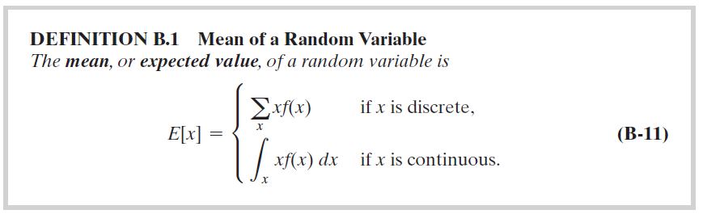

For a [uniformly distributed](https://en.wikipedia.org/wiki/Continuous_uniform_distribution) random variable the probability density function (PDF) is:

$$ f(x)=\left\{\begin{array}{l} \frac{1}{\theta_{2}-\theta_{1}}, \quad \text { if } \quad \theta_{1} \leq x \leq \theta_{2} \\ 0, \quad \text { otherwise } \end{array}\right. $$

Therefore:

$$ \begin{aligned} E[Y]&=\int_{\theta_{1}}^{\theta_{2}} Y f(Y) d Y =\int_{\theta_{1}}^{\theta_{2}} Y \frac{1}{\theta_{2}-\theta_{1}} d Y =\frac{1}{\theta_{2}-\theta_{1}} \int_{\theta_{1}}^{\theta_{2}} Y d Y \\ &=\left.\frac{1}{\theta_{2}-\theta_{1}} \frac{Y^{2}}{2}\right|_{\theta_{1}} ^{\theta_{2}} =\frac{1}{\theta_{2}-\theta_{1}} \frac{\theta_{2}^{2}-\theta_{1}^{2}}{2} =\frac{\left(\theta_{2}-\theta_{1}\right)\left(\theta_{2}+\theta_{1}\right)}{2\left(\theta_{2}-\theta_{1}\right)} =\frac{\theta_{2}+\theta_{1}}{2} \\ & QED \end{aligned} $$

### Problem 2:

Consider an experiment that consists of tossing a die and flipping a coin at the same time. Consider the following random variables:

$X_1$: The number of dots appearing on the die.

$X_2$: The sum of the number of dots on the die and the indicator for the coin, where the value of a head is 1 and the value of a tail is zero.

a) How many possible events are there, and what are they? What are the possible outcomes and associated probabilities for $X_2$ ?

The tree diagram for this experiment is:

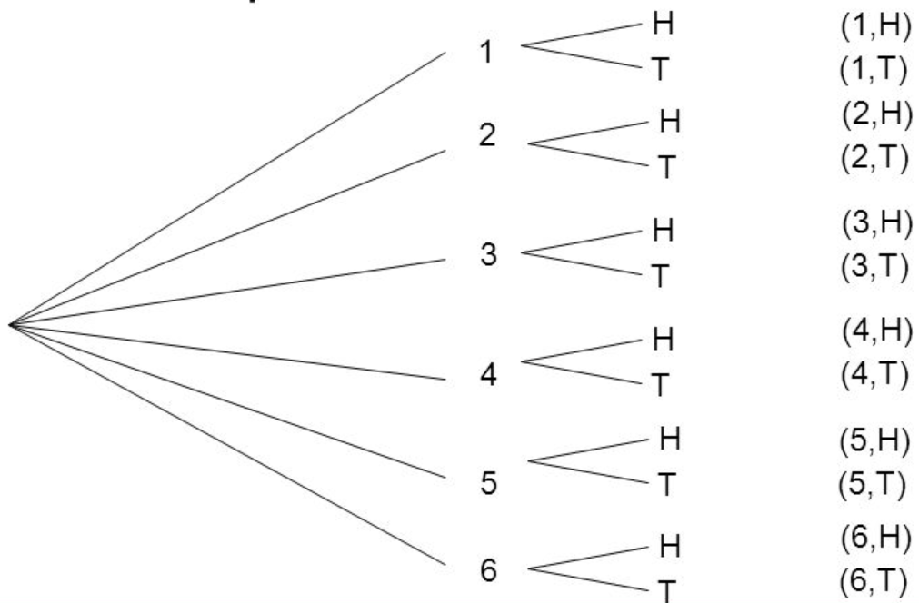

With Head = 1 and Tail = 0 the possible event space E is $$ \left(\begin{array}{c} (1,0),(2,0),(3,0),(4,0),(5,0),(6,0) \\ (1,1),(2,1),(3,1),(4,1),(5,1),(6,1) \end{array}\right) $$

thus a total of 12 possible events.

The corresponding possible values for $X_2$ are then: $$ \left(\begin{array}{c} (1),(2),(3),(4),(5),(6) \\ (2),(3),(4),(5),(6),(7) \end{array}\right) $$

Tabulating, the possible outcomes and associated Pabilities for $X_2$ are:

| Value | Pability |  |
| --- | --- | --- |
| 1 | 1/12 |  |
| 2 | 1/6 |  |
| 3 | 1/6 |  |
| 4 | 1/6 |  |
| 5 | 1/6 |  |
| 6 | 1/6 |  |
| 7 | 1/12 |  |

Alternately, define random variable $C \equiv$ coin toss outcome. Then,

$$ \begin{aligned} P\left(X_{2}=1\right)&=P\left(X_{1}=1\right) \times P(C=0)=\frac{1}{6} \cdot \frac{1}{2}=\frac{1}{12} \\ P\left(X_{2}=2\right)&=P\left(X_{1}=1\right) \times P(C=1)+P\left(X_{1}=2\right) \times P(C=0)=\frac{1}{12}+\frac{1}{12}=\frac{1}{6} \\ P\left(X_{2}=3\right)&=P\left(X_{1}=2\right) \times P(C=1)+P\left(X_{1}=3\right) \times P(C=0)=\frac{1}{12}+\frac{1}{12}=\frac{1}{6} \\ \vdots \\ P\left(X_{2}=7\right)&=P\left(X_{1}=6\right) \times P(C=1)=\frac{1}{12} \end{aligned} $$

b) What is the P($X_1$=3, $X_2$=3)?

First note that $P(X_1=3, X_2=3) \neq P(X_1=3)\times P(X_2=3)$. This is because $X_2$ is a function of $X_1$ which means the two random variables **ARE NOT** independent. Per [Greene Appendix B](http://pages.stern.nyu.edu/~wgreene/Text/Greene-EA-7&8ed-Appendices.pdf):

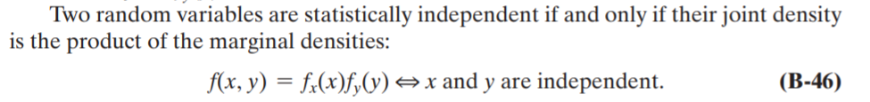

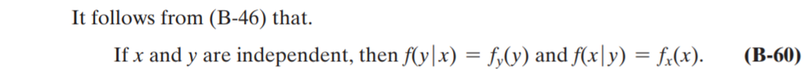

In our case $P(X_2)$ depends on $X_1$ then $P(X_2 | X_1)\neq P(X_2)$. However, the bivariate conditional density is defined (see [Greene Appendix B](http://pages.stern.nyu.edu/~wgreene/Text/Greene-EA-7&8ed-Appendices.pdf) or [here](https://en.wikipedia.org/wiki/Conditional_probability)) as:

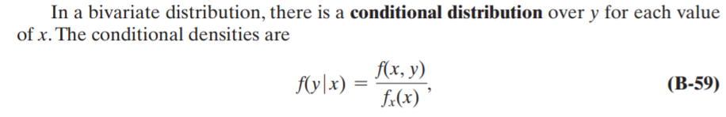

Therefore, $$ P(X_2 = 3 | X_1=3) = \frac {P(X_1 = 3, X_2=3)}{P(X_1=3)} $$

Since $P(X_2 = 3 | X_1=3)=\frac{1}{2}$, i.e. the probability of the coin flip being 0, we have: $$ \begin{aligned} P(X_1 = 3 , X_2=3) &= P(X_1=3) \times P(X_2 = 3 | X_1=3) = \frac{1}{6} \times \frac{1}{2}=\frac{1}{12} \end{aligned} $$

[figure not shown]